# *DATA ANALYSIS ON FOOD LABELS*

figure 32:

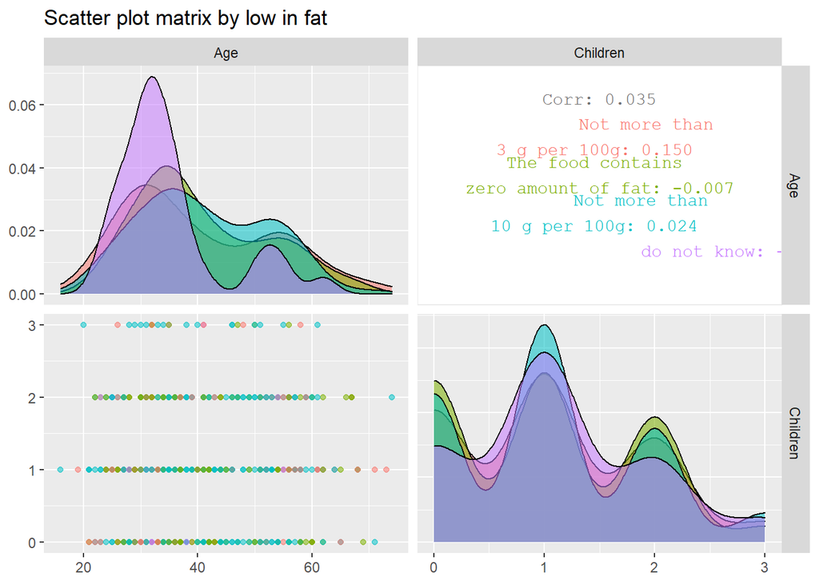

```r
 ggpairs(food_label, mapping = aes(color=`low in fat`, alpha =0.2),
         columns =c ("Age", "Children"))+
   ggtitle("Scatter plot matrix by low in fat")
```

There is no any strong linear relationships.

figure 33:

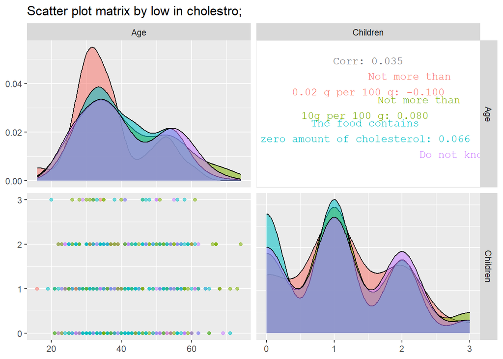

```r
 ggpairs(food_label, mapping = aes(color=`low in cho`, alpha =0.2),
         columns =c ("Age", "Children"))+
   ggtitle("Scatter plot matrix by low in cholestro;")
```

figure 34:

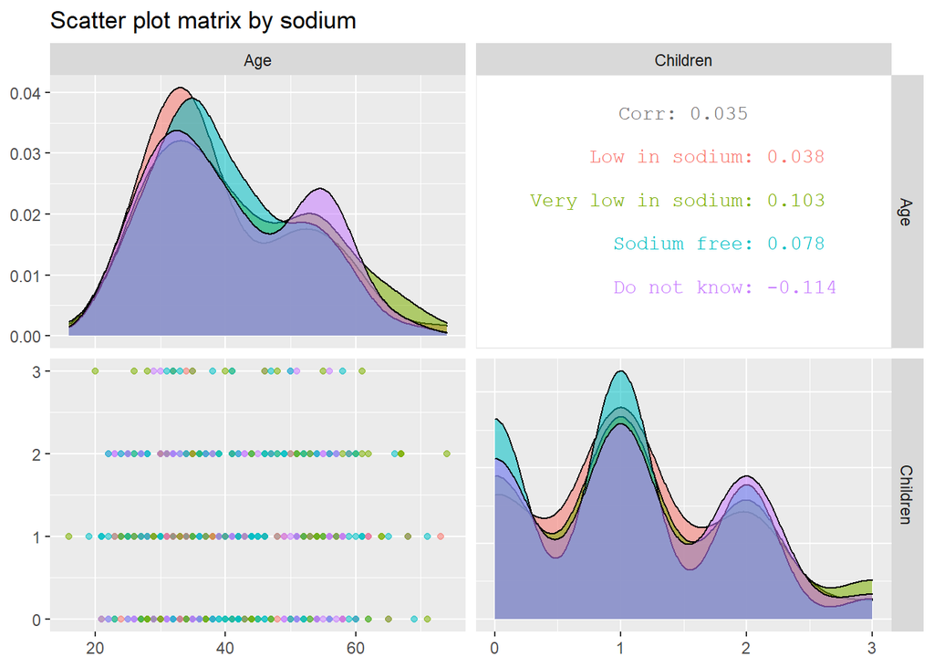

```r
 ggpairs(food_label, mapping = aes(color=sodium, alpha =0.2),
         columns =c ("Age", "Children"))+
   ggtitle("Scatter plot matrix by sodium")
```

There is no any strong linear relationships.

figure 35:

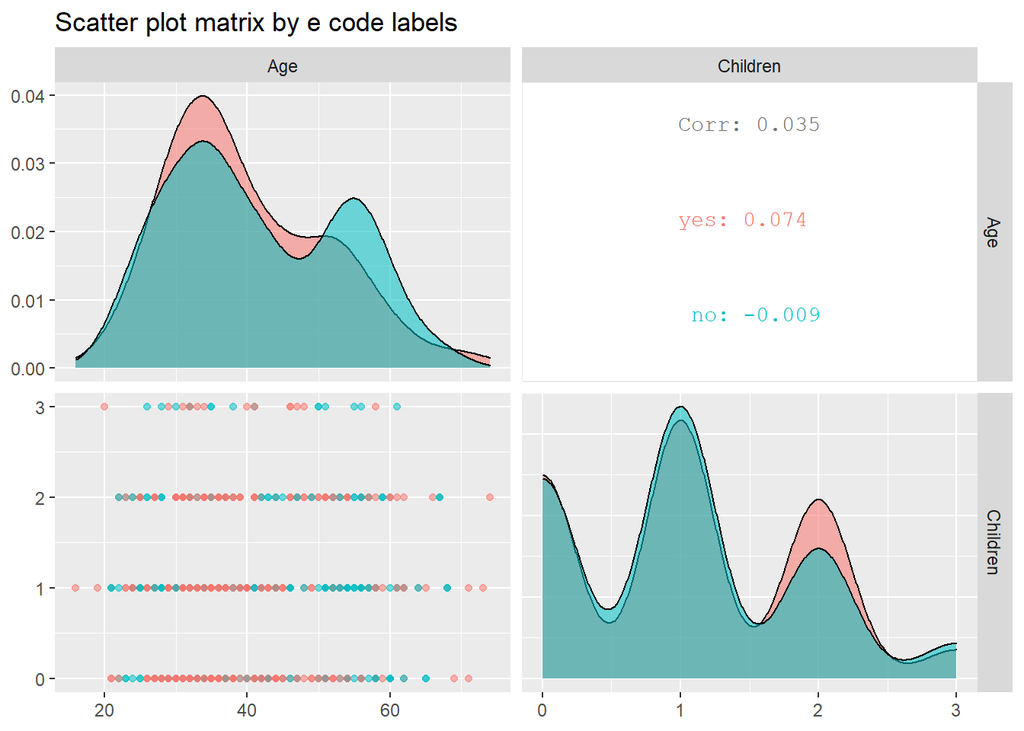

```r
 ggpairs(food_label, mapping = aes(color=`e labels`, alpha =0.2),
         columns =c ("Age", "Children"))+
   ggtitle("Scatter plot matrix by e code labels")
```

There is no any strong linear relationships.

```r
chiTable2 <- hux(
        Variable = c("Gender", "Education", "Employment", "Income", "Housesize" ,
                     "marital" ,"fshopper","mplanner" , "FA" ,"Diabetes" ,
                     "Metabolic_cyndrents", "Other", "specific","job1", "job2",
                     "Exercise" ,"Health", "place" ),
         netquan      = c(0.0000022,0.02227,0.2817,0.2911,0.8782,0.8696,0.2416,0.00002215,
                          0.1918,0.09066,0.03316,0.2741,0.2146,0.359,0.9124,0.3473,0.2398,0.2362),
        `low in fat`  = c(0.6385,0.09762,0.01041,0.41,0.171,0.2026,0.8417,0.8827,0.1397,0.8424,
                          0.9086,07869,0.6499,0.4867,0.5765,0.4409,0.7246,0.7535),
        `low in cho`  = c(0.2424,0.8388,0.5437,0.6919,0.1802,05666,0.1249,0.9328,05077,0.1007,0.4358,
                          0.296,0.5847,0.7082,0.7609,0.9345,0.1352,0.557),
         sodium       = c(0.01948,0.05121,0.001036,0.3894,0.4591,0.5783,0.6344,0.105,0.08301,0.6761,
                          0.4012,0.3476,0.1286,0.7007,0.7472,0.3076,0.1766,0.626),
        `e labels`    = c(0.0318,0.000000003251,0.1029,0.03139,0.8,0.05442,0.3435,0.7828,1,0.4325,0.1639,
                          0.8746,0.7086,0.007165,0.8449,0.0003601,0.901,0.04643),

        add_colnames = TRUE
                )
```

table 17:

```r
      caption(chiTable2) <- "Chi square statistics - p values"
     bold(chiTable2)[1,]           <- TRUE
   bottom_border(chiTable2)[1,]  <- TRUE

   chiTable2
```

Chi square statistics - p values

| Variable | netquan | low in fat | low in cho | sodium | e labels |
| --- | --- | --- | --- | --- | --- |
| Gender | 2.2e-06 | 0.638 | 0.242 | 0.0195 | 0.0318 |
| Education | 0.0223 | 0.0976 | 0.839 | 0.0512 | 3.25e-09 |
| Employment | 0.282 | 0.0104 | 0.544 | 0.00104 | 0.103 |
| Income | 0.291 | 0.41 | 0.692 | 0.389 | 0.0314 |
| Housesize | 0.878 | 0.171 | 0.18 | 0.459 | 0.8 |
| marital | 0.87 | 0.203 | 5.67e+03 | 0.578 | 0.0544 |
| fshopper | 0.242 | 0.842 | 0.125 | 0.634 | 0.344 |
| mplanner | 2.21e-05 | 0.883 | 0.933 | 0.105 | 0.783 |
| FA | 0.192 | 0.14 | 5.08e+03 | 0.083 | 1 |
| Diabetes | 0.0907 | 0.842 | 0.101 | 0.676 | 0.432 |
| Metabolic_cyndrents | 0.0332 | 0.909 | 0.436 | 0.401 | 0.164 |
| Other | 0.274 | 7.87e+03 | 0.296 | 0.348 | 0.875 |
| specific | 0.215 | 0.65 | 0.585 | 0.129 | 0.709 |
| job1 | 0.359 | 0.487 | 0.708 | 0.701 | 0.00717 |
| job2 | 0.912 | 0.577 | 0.761 | 0.747 | 0.845 |
| Exercise | 0.347 | 0.441 | 0.934 | 0.308 | 0.00036 |
| Health | 0.24 | 0.725 | 0.135 | 0.177 | 0.901 |
| place | 0.236 | 0.753 | 0.557 | 0.626 | 0.0464 |

According to table 17,

**Net quantity and Gender-**

Since pvalue = 2.2e-06 < 0.05 we have enough evidence to reject H0 at 5% level of significance. Net quantity and Gender are dependent.

**Net quantity and Education-**

Since pvalue = 0.0223 < 0.05 we have enough evidence to reject H0 at 5% level of significance. Net quantity and Education are dependent.

**Net quantity and Metabolic cyndrents-**

Since pvalue = 0.0332 < 0.05 we have enough evidence to reject H0 at 5% level of significance. Net quantity and Metabolic cyndrents are dependent.

**Low in fat and Employment level-**

Since pvalue = 0.0104 < 0.05 we have enough evidence to reject H0 at 5% level of significance. Low in fat and Employment level are dependent.

**Sodium and Gender-**

Since pvalue = 0.01948 < 0.05 we have enough evidence to reject H0 at 5% level of significance. Sodium and Gender are dependent.

**sodium and Employment level-**

Since pvalue = 0.001036 < 0.05 we have enough evidence to reject H0 at 5% level of significance. sodium and Employment level are dependent.

**E label and Gender-**

Since pvalue = 0.0318 < 0.05 we have enough evidence to reject H0 at 5% level of significance. E label and Gender are dependent.

**E label and Education-**

Since pvalue = 3.25e-09 < 0.05 we have enough evidence to reject H0 at 5% level of significance. E label and Education are dependent.

**E label and Income-**

Since pvalue = 0.03139 < 0.05 we have enough evidence to reject H0 at 5% level of significance. E label and Income are dependent.

**E label and Job 1-**

Since pvalue = 0.007165 < 0.05 we have enough evidence to reject H0 at 5% level of significance. E label and Job 1 are dependent.

**E label and Exercise-**

Since pvalue = 0.0003601 < 0.05 we have enough evidence to reject H0 at 5% level of significance. E label and Exercise are dependent.

**E label and place-**

Since pvalue = 0.04643 < 0.05 we have enough evidence to reject H0 at 5% level of significance. E label and place are dependent.

#### References

- https://hellor.netlify.com/
- https://tstdataviz.netlify.app/
- https://data-flair.training/blogs/chi-square-test-in-r/#:~:text=Chi%2DSquare%20test%20in%20R%20is%20a%20statistical%20method%20which,selected%20from%20the%20same%20population.
- http://www.sthda.com/english/wiki/chi-square-test-of-independence-in-r